# Which one is a better plan?

You work as an analyst for the telecom operator Megaline. The company offers its clients two prepaid plans, Surf and Ultimate. The commercial department wants to know which of the plans brings in more revenue in order to adjust the advertising budget.

You are going to carry out a preliminary analysis of the plans based on a relatively small client selection. You'll have the data on 500 Megaline clients: who the clients are, where they're from, which plan they use, and the number of calls they made and text messages they sent in 2018. Your job is to analyze the clients' behavior and determine which prepaid plan brings in more revenue.

## Initialization

```python
# Loading all the libraries
from scipy import stats as st
import numpy as np
from matplotlib import pyplot as plt
from math import factorial
import pandas as pd
```

## Load data

```python
# Load the data files into different DataFrames
calls = pd.read_csv('/datasets/megaline_calls.csv')
internet = pd.read_csv('/datasets/megaline_internet.csv')
messages = pd.read_csv('/datasets/megaline_messages.csv')
plans = pd.read_csv('/datasets/megaline_plans.csv')
users = pd.read_csv('/datasets/megaline_users.csv')
```

## Prepare the data

[The data for this project is split into several tables. Explore each one to get an initial understanding of the data. Do necessary corrections to each table if necessary.]

## Plans

```python
# Print the general/summary information about the plans' DataFrame
plans.info()
```

```
<class 'pandas.core.frame.DataFrame'>
RangeIndex: 2 entries, 0 to 1
Data columns (total 8 columns):
 #   Column                 Non-Null Count  Dtype
---  ------                 --------------  -----
 0   messages_included      2 non-null      int64
 1   mb_per_month_included  2 non-null      int64
 2   minutes_included       2 non-null      int64
 3   usd_monthly_pay        2 non-null      int64
 4   usd_per_gb             2 non-null      int64
 5   usd_per_message        2 non-null      float64
 6   usd_per_minute         2 non-null      float64
 7   plan_name              2 non-null      object
dtypes: float64(2), int64(5), object(1)
memory usage: 256.0+ bytes
```

```python
# Print a sample of data for plans
plans.head()
```

|  | messages_included | mb_per_month_included | minutes_included | usd_monthly_pay | usd_per_gb | usd_per_message | usd_per_minute | plan_name |
| --- | --- | --- | --- | --- | --- | --- | --- | --- |
| 0 | 50 | 15360 | 500 | 20 | 10 | 0.03 | 0.03 | surf |
| 1 | 1000 | 30720 | 3000 | 70 | 7 | 0.01 | 0.01 | ultimate |

[Describe what you see and notice in the general information and the printed data sample for the above price of data. Are there any issues (inappropriate data types, missing data etc) that may need further investigation and changes? How that can be fixed?]

According to plans.info() usd_per_gb is an int64 datatype.Tho we could still combine the int64 and float64 varibles and they would be converted to float64. I could also go ahead and turn that column into float64 using the astype() method. Other then that I can see that we have no NaN values, 8 columns and 2 rows.

## Fix data

[Fix obvious issues with the data given the initial observations.]

```python
plans['usd_per_gb'] = plans['usd_per_gb'].astype('float64')
```

## Enrich data

[Add additional factors to the data if you believe they might be useful.]

## Users

```python
# Print the general/summary information about the users' DataFrame
users.info()
```

```
<class 'pandas.core.frame.DataFrame'>
RangeIndex: 500 entries, 0 to 499
Data columns (total 8 columns):
 #   Column      Non-Null Count  Dtype
---  ------      --------------  -----
 0   user_id     500 non-null    int64
 1   first_name  500 non-null    object
 2   last_name   500 non-null    object
 3   age         500 non-null    int64
 4   city        500 non-null    object
 5   reg_date    500 non-null    object
 6   plan        500 non-null    object
 7   churn_date  34 non-null     object
dtypes: int64(2), object(6)
memory usage: 31.4+ KB
```

```python
# Print a sample of data for users
users.head(15)

duplicates = users[users.duplicated(subset='user_id', keep=False)]
total_duplicates = len(duplicates)
print(total_duplicates)
```

```
0
```

[Describe what you see and notice in the general information and the printed data sample for the above price of data. Are there any issues (inappropriate data types, missing data etc) that may need further investigation and changes? How that can be fixed?]

First we notice that we have a total of 500 entries(rows) and a total of 8 columns. I also notice that the city column has in some entires multiple cities and in some multiple cities and states. This may be an issue later on depending on what we decide to do with the data but as of right now i dont think it will be an issue. One fix may be to split up and make seperate entries for each city with the same other data including user id and such. Another thing I found is that the reg_date and churn_date are not of the date-time type. That can be changed using the to_datetime() method. Lastly the NaN values in churn_date could be replaced with a 0000-00-00 placeholder to keep uniformity but know that its a null value. I could also make a new column that just holds the user ids with NaN curn_values. Im also going to change plan to plan_name so i can merge the datasets later if i need too.

### Fix Data

[Fix obvious issues with the data given the initial observations.]

```python
users['reg_date'] = pd.to_datetime(users['reg_date'], format='%Y-%m-%d')
users = users.rename(columns={'plan' : 'plan_name'})
print(users.head())
```

```
   user_id first_name  last_name  age                                   city  \
0     1000   Anamaria      Bauer   45  Atlanta-Sandy Springs-Roswell, GA MSA
1     1001     Mickey  Wilkerson   28        Seattle-Tacoma-Bellevue, WA MSA
2     1002     Carlee    Hoffman   36   Las Vegas-Henderson-Paradise, NV MSA
3     1003   Reynaldo    Jenkins   52                          Tulsa, OK MSA
4     1004    Leonila   Thompson   40        Seattle-Tacoma-Bellevue, WA MSA

    reg_date plan_name churn_date
0 2018-12-24  ultimate        NaN
1 2018-08-13      surf        NaN
2 2018-10-21      surf        NaN
3 2018-01-28      surf        NaN
4 2018-05-23      surf        NaN
```

```python
# Reviewer's code 2

pd.read_csv('/datasets/megaline_calls.csv', parse_dates=['call_date'])
```

|  | id | user_id | call_date | duration |
| --- | --- | --- | --- | --- |
| 0 | 1000_93 | 1000 | 2018-12-27 | 8.52 |
| 1 | 1000_145 | 1000 | 2018-12-27 | 13.66 |
| 2 | 1000_247 | 1000 | 2018-12-27 | 14.48 |
| 3 | 1000_309 | 1000 | 2018-12-28 | 5.76 |
| 4 | 1000_380 | 1000 | 2018-12-30 | 4.22 |
| ... | ... | ... | ... | ... |
| 137730 | 1499_199 | 1499 | 2018-11-21 | 8.72 |
| 137731 | 1499_200 | 1499 | 2018-10-20 | 10.89 |
| 137732 | 1499_201 | 1499 | 2018-09-21 | 8.12 |
| 137733 | 1499_202 | 1499 | 2018-10-10 | 0.37 |
| 137734 | 1499_203 | 1499 | 2018-12-29 | 13.86 |

137735 rows × 4 columns

### Enrich Data

[Add additional factors to the data if you believe they might be useful.]

```python
users['null_churn_date'] = users['churn_date'].where(users['churn_date'].isna(), np.nan)
users['churn_date']= pd.to_datetime(users['churn_date'], format='%Y-%m-%d')
users.info()
```

```
<class 'pandas.core.frame.DataFrame'>
RangeIndex: 500 entries, 0 to 499
Data columns (total 9 columns):
 #   Column           Non-Null Count  Dtype
---  ------           --------------  -----
 0   user_id          500 non-null    int64
 1   first_name       500 non-null    object
 2   last_name        500 non-null    object
 3   age              500 non-null    int64
 4   city             500 non-null    object
 5   reg_date         500 non-null    datetime64[ns]
 6   plan_name        500 non-null    object
 7   churn_date       34 non-null     datetime64[ns]
 8   null_churn_date  0 non-null      object
dtypes: datetime64[ns](2), int64(2), object(5)
memory usage: 35.3+ KB
```

## Calls

```python
# Print the general/summary information about the calls' DataFrame
calls.info()
```

```
<class 'pandas.core.frame.DataFrame'>
RangeIndex: 137735 entries, 0 to 137734
Data columns (total 4 columns):
 #   Column     Non-Null Count   Dtype
---  ------     --------------   -----
 0   id         137735 non-null  object
 1   user_id    137735 non-null  int64
 2   call_date  137735 non-null  object
 3   duration   137735 non-null  float64
dtypes: float64(1), int64(1), object(2)
memory usage: 4.2+ MB
```

```python
# Print a sample of data for calls
calls.head(20)
```

|  | id | user_id | call_date | duration |
| --- | --- | --- | --- | --- |
| 0 | 1000_93 | 1000 | 2018-12-27 | 8.52 |
| 1 | 1000_145 | 1000 | 2018-12-27 | 13.66 |
| 2 | 1000_247 | 1000 | 2018-12-27 | 14.48 |
| 3 | 1000_309 | 1000 | 2018-12-28 | 5.76 |
| 4 | 1000_380 | 1000 | 2018-12-30 | 4.22 |
| 5 | 1000_388 | 1000 | 2018-12-31 | 2.20 |
| 6 | 1000_510 | 1000 | 2018-12-27 | 5.75 |
| 7 | 1000_521 | 1000 | 2018-12-28 | 14.18 |
| 8 | 1000_530 | 1000 | 2018-12-28 | 5.77 |
| 9 | 1000_544 | 1000 | 2018-12-26 | 4.40 |
| 10 | 1000_693 | 1000 | 2018-12-31 | 4.31 |
| 11 | 1000_705 | 1000 | 2018-12-31 | 12.78 |
| 12 | 1000_735 | 1000 | 2018-12-29 | 1.70 |
| 13 | 1000_778 | 1000 | 2018-12-28 | 3.29 |
| 14 | 1000_826 | 1000 | 2018-12-26 | 9.96 |
| 15 | 1000_842 | 1000 | 2018-12-27 | 5.85 |
| 16 | 1001_0 | 1001 | 2018-09-06 | 10.06 |
| 17 | 1001_1 | 1001 | 2018-10-12 | 1.00 |
| 18 | 1001_2 | 1001 | 2018-10-17 | 15.83 |
| 19 | 1001_4 | 1001 | 2018-12-05 | 0.00 |

[Describe what you see and notice in the general information and the printed data sample for the above price of data. Are there any issues (inappropriate data types, missing data etc) that may need further investigation and changes? How that can be fixed?]

The call_date column is an object and should be changed to date time.

### Fix data

[Fix obvious issues with the data given the initial observations.]

```python
calls['call_date']= pd.to_datetime(calls['call_date'], format='%Y-%m-%d')

calls.info()
```

```
<class 'pandas.core.frame.DataFrame'>
RangeIndex: 137735 entries, 0 to 137734
Data columns (total 4 columns):
 #   Column     Non-Null Count   Dtype
---  ------     --------------   -----
 0   id         137735 non-null  object
 1   user_id    137735 non-null  int64
 2   call_date  137735 non-null  datetime64[ns]
 3   duration   137735 non-null  float64
dtypes: datetime64[ns](1), float64(1), int64(1), object(1)
memory usage: 4.2+ MB
```

## Messages

```python
# Print the general/summary information about the messages' DataFrame
messages.info()
```

```
<class 'pandas.core.frame.DataFrame'>
RangeIndex: 76051 entries, 0 to 76050
Data columns (total 3 columns):
 #   Column        Non-Null Count  Dtype
---  ------        --------------  -----
 0   id            76051 non-null  object
 1   user_id       76051 non-null  int64
 2   message_date  76051 non-null  object
dtypes: int64(1), object(2)
memory usage: 1.7+ MB
```

```python
# Print a sample of data for messages
messages.head(10)
```

|  | id | user_id | message_date |
| --- | --- | --- | --- |
| 0 | 1000_125 | 1000 | 2018-12-27 |
| 1 | 1000_160 | 1000 | 2018-12-31 |
| 2 | 1000_223 | 1000 | 2018-12-31 |
| 3 | 1000_251 | 1000 | 2018-12-27 |
| 4 | 1000_255 | 1000 | 2018-12-26 |
| 5 | 1000_346 | 1000 | 2018-12-29 |
| 6 | 1000_386 | 1000 | 2018-12-30 |
| 7 | 1000_413 | 1000 | 2018-12-31 |
| 8 | 1000_502 | 1000 | 2018-12-27 |
| 9 | 1000_525 | 1000 | 2018-12-28 |

I see the message_date column is not in date time format.

### Fix data

```python
messages['message_date']= pd.to_datetime(messages['message_date'], format='%Y-%m-%d')
```

## Internet

```python
# Print the general/summary information about the internet DataFrame
internet.info()
```

```
<class 'pandas.core.frame.DataFrame'>
RangeIndex: 104825 entries, 0 to 104824
Data columns (total 4 columns):
 #   Column        Non-Null Count   Dtype
---  ------        --------------   -----
 0   id            104825 non-null  object
 1   user_id       104825 non-null  int64
 2   session_date  104825 non-null  object
 3   mb_used       104825 non-null  float64
dtypes: float64(1), int64(1), object(2)
memory usage: 3.2+ MB
```

```python
# Print a sample of data for the internet traffic
internet.head(10)
```

|  | id | user_id | session_date | mb_used |
| --- | --- | --- | --- | --- |
| 0 | 1000_13 | 1000 | 2018-12-29 | 89.86 |
| 1 | 1000_204 | 1000 | 2018-12-31 | 0.00 |
| 2 | 1000_379 | 1000 | 2018-12-28 | 660.40 |
| 3 | 1000_413 | 1000 | 2018-12-26 | 270.99 |
| 4 | 1000_442 | 1000 | 2018-12-27 | 880.22 |
| 5 | 1001_0 | 1001 | 2018-08-24 | 284.68 |
| 6 | 1001_3 | 1001 | 2018-12-09 | 656.04 |
| 7 | 1001_4 | 1001 | 2018-11-04 | 16.97 |
| 8 | 1001_10 | 1001 | 2018-11-27 | 135.18 |
| 9 | 1001_15 | 1001 | 2018-12-13 | 761.92 |

Session date should be of date type type.

### Fix data

```python
internet['session_date']= pd.to_datetime(internet['session_date'], format='%Y-%m-%d')
```

## Study plan conditions

```python
# Print out the plan conditions and make sure they are clear for you
print('''Note: Megaline rounds seconds up to minutes, and megabytes to gigabytes. For calls, each individual call is rounded up: even if the call lasted just one second, it will be counted as one minute. For web traffic, individual web sessions are not rounded up. Instead, the total for the month is rounded up. If someone uses 1025 megabytes this month, they will be charged for 2 gigabytes.

Surf

Monthly charge: $20
500 monthly minutes, 50 texts, and 15 GB of data
After exceeding the package limits:
1 minute: 3 cents
1 text message: 3 cents
1 GB of data: $10
Ultimate

Monthly charge: $70
3000 monthly minutes, 1000 text messages, and 30 GB of data
After exceeding the package limits:
1 minute: 1 cent
1 text message: 1 cent
1 GB of data: $7''')
```

[output not shown]

## Aggregate data per user

```python
# Calculate the number of calls made by each user per month. Save the result.

# Extract the month from the 'call_date'
calls['month'] = calls['call_date'].dt.month

# Group by 'user_id' and 'month', then count the number of calls for each group
calls_per_user = calls.groupby(['user_id', 'month','duration']).size().reset_index(name='call_count')

# Print the result
print(calls_per_user)
```

```
        user_id  month  duration  call_count
0          1000     12      1.70           1
1          1000     12      2.20           1
2          1000     12      3.29           1
3          1000     12      4.22           1
4          1000     12      4.31           1
...         ...    ...       ...         ...
111276     1499     12     16.49           1
111277     1499     12     16.92           1
111278     1499     12     17.31           1
111279     1499     12     18.17           1
111280     1499     12     22.24           1

[111281 rows x 4 columns]
```

```python
# Calculate the amount of minutes spent by each user per month. Save the result.
calls['duration'] = np.ceil(calls['duration'])

total_minutes_per_user = calls.groupby(['user_id', 'month'])['duration'].agg(['count', 'sum'])

total_minutes_per_user = total_minutes_per_user.rename(columns={'count': 'total_calls', 'sum': 'total_minutes'})
total_minutes_per_user
```

| user_id | month | total_calls | total_minutes |
| --- | --- | --- | --- |
| 1000 | 12 | 16 | 124.0 |
| 1001 | 8 | 27 | 182.0 |
|  | 9 | 49 | 315.0 |
|  | 10 | 65 | 393.0 |
|  | 11 | 64 | 426.0 |
| ... | ... | ... | ... |
| 1498 | 12 | 39 | 339.0 |
| 1499 | 9 | 41 | 346.0 |
|  | 10 | 53 | 385.0 |
|  | 11 | 45 | 308.0 |
|  | 12 | 65 | 496.0 |

2258 rows × 2 columns

```python
# Reviewer's code

calls.groupby(['user_id', 'month'])['duration'].agg(['count', 'sum'])
```

| user_id | month | count | sum |
| --- | --- | --- | --- |
| 1000 | 12 | 16 | 124.0 |
| 1001 | 8 | 27 | 182.0 |
|  | 9 | 49 | 315.0 |
|  | 10 | 65 | 393.0 |
|  | 11 | 64 | 426.0 |
| ... | ... | ... | ... |
| 1498 | 12 | 39 | 339.0 |
| 1499 | 9 | 41 | 346.0 |
|  | 10 | 53 | 385.0 |
|  | 11 | 45 | 308.0 |
|  | 12 | 65 | 496.0 |

2258 rows × 2 columns

```python
# Reviewer's code

display(calls.head(3))

calls.tail(3)
```

|  | id | user_id | call_date | duration | month |
| --- | --- | --- | --- | --- | --- |
| 0 | 1000_93 | 1000 | 2018-12-27 | 9.0 | 12 |
| 1 | 1000_145 | 1000 | 2018-12-27 | 14.0 | 12 |
| 2 | 1000_247 | 1000 | 2018-12-27 | 15.0 | 12 |

|  | id | user_id | call_date | duration | month |
| --- | --- | --- | --- | --- | --- |
| 137732 | 1499_201 | 1499 | 2018-09-21 | 9.0 | 9 |
| 137733 | 1499_202 | 1499 | 2018-10-10 | 1.0 | 10 |
| 137734 | 1499_203 | 1499 | 2018-12-29 | 14.0 | 12 |

```python
# Calculate the number of messages sent by each user per month. Save the result.
messages['month'] = messages['message_date'].dt.month

total_messages = messages.groupby(['user_id', 'month'])['id'].count().rename('total_messages_per_month')

total_messages
```

```
user_id  month
1000     12       11
1001     8        30
         9        44
         10       53
         11       36
                  ..
1496     9        21
         10       18
         11       13
         12       11
1497     12       50
Name: total_messages_per_month, Length: 1806, dtype: int64
```

```python
# Calculate the volume of internet traffic used by each user per month. Save the result.
internet['month'] = internet['session_date'].dt.month
traffic_vol = internet.groupby(['user_id', 'month'])['mb_used'].sum()
traffic_vol
```

```
user_id  month
1000     12        1901.47
1001     8         6919.15
         9        13314.82
         10       22330.49
         11       18504.30
                    ...
1498     12       23137.69
1499     9        12984.76
         10       19492.43
         11       16813.83
         12       22059.21
Name: mb_used, Length: 2277, dtype: float64
```

[Put the aggregate data together into one DataFrame so that one record in it would represent what an unique user consumed in a given month.]

```python
# Merge the data for calls, minutes, messages, internet based on user_id and month

merged_df = pd.merge(calls_per_user, total_messages, on=['user_id', 'month'], how='outer')

merged_df = pd.merge(merged_df, total_minutes_per_user, on=['user_id', 'month'], how='outer')

call_message_internet =pd.merge(merged_df, traffic_vol, on=['user_id', 'month'], how='outer')

call_message_internet.fillna(0, inplace=True)

call_message_internet['mb_used'] = np.ceil(call_message_internet['mb_used'])

call_message_internet = call_message_internet.groupby(['user_id', 'month','mb_used']).agg({
    'total_minutes': 'first',
    'total_messages_per_month': 'first'
}).reset_index()
call_message_internet
```

|  | user_id | month | mb_used | total_minutes | total_messages_per_month |
| --- | --- | --- | --- | --- | --- |
| 0 | 1000 | 12 | 1902.0 | 124.0 | 11.0 |
| 1 | 1001 | 8 | 6920.0 | 182.0 | 30.0 |
| 2 | 1001 | 9 | 13315.0 | 315.0 | 44.0 |
| 3 | 1001 | 10 | 22331.0 | 393.0 | 53.0 |
| 4 | 1001 | 11 | 18505.0 | 426.0 | 36.0 |
| ... | ... | ... | ... | ... | ... |
| 2288 | 1498 | 12 | 23138.0 | 339.0 | 0.0 |
| 2289 | 1499 | 9 | 12985.0 | 346.0 | 0.0 |
| 2290 | 1499 | 10 | 19493.0 | 385.0 | 0.0 |
| 2291 | 1499 | 11 | 16814.0 | 308.0 | 0.0 |
| 2292 | 1499 | 12 | 22060.0 | 496.0 | 0.0 |

2293 rows × 5 columns

```python
# Add the plan information

user_ids_plans = users[['user_id', 'plan_name']]


plans_users =  pd.merge(user_ids_plans, plans, on=['plan_name'], how='outer')

#plan_name_with_user_id = plans_users.groupby('user_id')

print(plans_users.head())

plan_users_counts = pd.merge(call_message_internet, plans_users, on=['user_id'], how='left')

print(plan_users_counts.head())
```

```
   user_id plan_name  messages_included  mb_per_month_included  \
0     1000  ultimate               1000                  30720
1     1006  ultimate               1000                  30720
2     1008  ultimate               1000                  30720
3     1011  ultimate               1000                  30720
4     1013  ultimate               1000                  30720

   minutes_included  usd_monthly_pay  usd_per_gb  usd_per_message  \
0              3000               70         7.0             0.01
1              3000               70         7.0             0.01
2              3000               70         7.0             0.01
3              3000               70         7.0             0.01
4              3000               70         7.0             0.01

   usd_per_minute
```

[output cut: 25 more lines]

```python
plan_users_counts
```

|  | user_id | month | mb_used | total_minutes | total_messages_per_month | plan_name | messages_included | mb_per_month_included | minutes_included | usd_monthly_pay | usd_per_gb | usd_per_message | usd_per_minute |
| --- | --- | --- | --- | --- | --- | --- | --- | --- | --- | --- | --- | --- | --- |
| 0 | 1000 | 12 | 1902.0 | 124.0 | 11.0 | ultimate | 1000 | 30720 | 3000 | 70 | 7.0 | 0.01 | 0.01 |
| 1 | 1001 | 8 | 6920.0 | 182.0 | 30.0 | surf | 50 | 15360 | 500 | 20 | 10.0 | 0.03 | 0.03 |
| 2 | 1001 | 9 | 13315.0 | 315.0 | 44.0 | surf | 50 | 15360 | 500 | 20 | 10.0 | 0.03 | 0.03 |
| 3 | 1001 | 10 | 22331.0 | 393.0 | 53.0 | surf | 50 | 15360 | 500 | 20 | 10.0 | 0.03 | 0.03 |
| 4 | 1001 | 11 | 18505.0 | 426.0 | 36.0 | surf | 50 | 15360 | 500 | 20 | 10.0 | 0.03 | 0.03 |
| ... | ... | ... | ... | ... | ... | ... | ... | ... | ... | ... | ... | ... | ... |
| 2288 | 1498 | 12 | 23138.0 | 339.0 | 0.0 | surf | 50 | 15360 | 500 | 20 | 10.0 | 0.03 | 0.03 |
| 2289 | 1499 | 9 | 12985.0 | 346.0 | 0.0 | surf | 50 | 15360 | 500 | 20 | 10.0 | 0.03 | 0.03 |
| 2290 | 1499 | 10 | 19493.0 | 385.0 | 0.0 | surf | 50 | 15360 | 500 | 20 | 10.0 | 0.03 | 0.03 |
| 2291 | 1499 | 11 | 16814.0 | 308.0 | 0.0 | surf | 50 | 15360 | 500 | 20 | 10.0 | 0.03 | 0.03 |
| 2292 | 1499 | 12 | 22060.0 | 496.0 | 0.0 | surf | 50 | 15360 | 500 | 20 | 10.0 | 0.03 | 0.03 |

2293 rows × 13 columns

```python
# Calculate the monthly revenue for each user


#he script calculates the monthly revenue from each user by subtracting the free package limits from the total number of calls, text messages, and data, multiplying the result by the calling plan value, and adding the monthly charge depending on the calling plan. Finally, it groups the results by user_id and calculates the total monthly revenue.

#plan_users_counts['revenue_messages'] = plan_users_counts.apply(lambda row: max(0, row['total_messages_per_month'] - row['messages_included']) * row['usd_per_message'], axis=1)
#plan_users_counts['revenue_mb'] = plan_users_counts.apply(lambda row: max(0, row['mb_used'] - row['mb_per_month_included']) / 1024 * row['usd_per_gb'], axis=1)
#plan_users_counts['revenue_mb'] = np.ceil(plan_users_counts['revenue_mb'])
#plan_users_counts['revenue_minutes'] = plan_users_counts.apply(lambda row: max(0, row['duration'] - row['minutes_included']) * row['usd_per_minute'], axis=1)
#plan_users_counts['total_revenue'] = plan_users_counts['usd_monthly_pay'] + plan_users_counts['revenue_messages'] + plan_users_counts['revenue_mb'] + plan_users_counts['revenue_minutes']
#plan_users_counts.head()
#print()
#print()
#print()
#print()
#monthly_revenue = plan_users_counts.groupby('user_id')['total_revenue'].sum().reset_index()
#monthly_revenue.head()
def calculate_monthly_revenue(plan_users_counts):
    """
    Calculate monthly revenue for each user based on usage and pricing.

    Parameters:
    plan_users_counts (pd.DataFrame): DataFrame with user data and pricing information.

    Returns:
    pd.DataFrame: DataFrame with calculated monthly revenue for each user.
   """
    def calculate_revenue(group):
        revenue_messages = max(0, group['total_messages_per_month'].sum() - group['messages_included'].mean()) * group['usd_per_message'].mean()
        revenue_mb = max(0, group['mb_used'].sum() - group['mb_per_month_included'].mean()) / 1024
        revenue_mb = np.ceil(revenue_mb) * group['usd_per_gb'].mean()
        revenue_minutes = max(0, (group['total_minutes'] - group['minutes_included']).mean() * group['usd_per_minute'].mean())

        total_revenue = group['usd_monthly_pay'].mean() + revenue_messages + revenue_mb + revenue_minutes
        return pd.Series({'total_revenue': total_revenue})

    result = plan_users_counts.groupby(['user_id', 'month']).apply(calculate_revenue).reset_index()
    return result

calculate_monthly_revenue(plan_users_counts).head(15)
```

|  | user_id | month | total_revenue |
| --- | --- | --- | --- |
| 0 | 1000 | 12 | 70.00 |
| 1 | 1001 | 8 | 20.00 |
| 2 | 1001 | 9 | 20.00 |
| 3 | 1001 | 10 | 90.09 |
| 4 | 1001 | 11 | 60.00 |
| 5 | 1001 | 12 | 60.00 |
| 6 | 1002 | 10 | 20.00 |
| 7 | 1002 | 11 | 60.00 |
| 8 | 1002 | 12 | 20.00 |
| 9 | 1003 | 12 | 158.12 |
| 10 | 1004 | 5 | 20.00 |
| 11 | 1004 | 6 | 80.00 |
| 12 | 1004 | 7 | 110.00 |
| 13 | 1004 | 8 | 150.00 |
| 14 | 1004 | 9 | 60.00 |

## Study user behaviour

### Calls

```
   plan_name  month  total_minutes
0       surf      1     203.000000
1       surf      2     297.000000
2       surf      3     330.000000
3       surf      4     351.540000
4       surf      5     399.584416
5       surf      6     431.298969
6       surf      7     449.983471
7       surf      8     410.111111
8       surf      9     414.226804
9       surf     10     429.729958
10      surf     11     423.325088
11      surf     12     473.836478
12  ultimate      1     193.500000
13  ultimate      2     403.142857
14  ultimate      3     304.250000
15  ultimate      4     336.857143
16  ultimate      5     406.241379
17  ultimate      6     370.957447
18  ultimate      7     427.067797
19  ultimate      8     421.436620
20  ultimate      9     437.511628
21  ultimate     10     450.735849
22  ultimate     11     445.196850
23  ultimate     12     459.099338
```

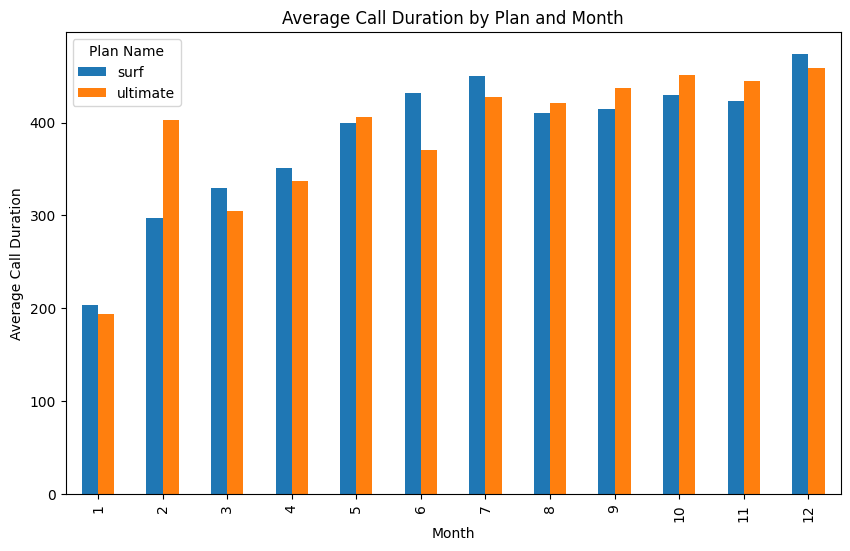

```python
# Compare average duration of calls per each plan per each distinct month. Plot a bar plat to visualize it.
avg_duration_by_plan_month = plan_users_counts.groupby(['plan_name', 'month'])['total_minutes'].mean().reset_index()
print(avg_duration_by_plan_month.head(24))
pivoted_data = avg_duration_by_plan_month.pivot(index='month', columns='plan_name', values='total_minutes')
pivoted_data.plot(kind='bar', figsize=(10, 6))
plt.xlabel('Month')
plt.ylabel('Average Call Duration')
plt.title('Average Call Duration by Plan and Month')
plt.legend(title='Plan Name')
plt.show()
```

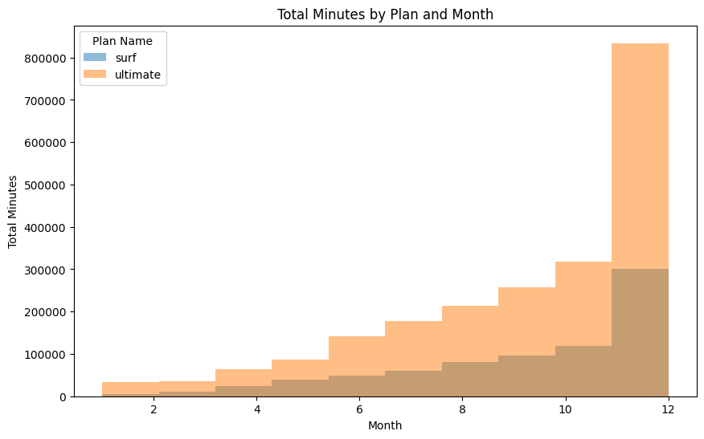

```python
# Compare the number of minutes users of each plan require each month. Plot a histogram.
minutes_by_plan_month = plan_users_counts.groupby(['plan_name', 'month'])['minutes_included'].sum().reset_index()

# plot a histogram
plt.figure(figsize=(10, 6))
for plan in minutes_by_plan_month['plan_name'].unique():
    plan_data = minutes_by_plan_month[minutes_by_plan_month['plan_name'] == plan]
    plt.hist(plan_data['month'], weights=plan_data['minutes_included'], alpha=0.5, label=plan)

plt.xlabel('Month')
plt.ylabel('Total Minutes')
plt.title('Total Minutes by Plan and Month')
plt.legend(title='Plan Name')
plt.show()
```

[Calculate the mean and the variable of the call duration to reason on whether users on the different plans have different behaviours for their calls.]

```python
# Calculate the mean and the variance of the monthly call duration


#monthly_call_duration_stats = plan_users_counts.groupby('month')['duration'].agg(['mean', 'var']).reset_index()


monthly_call_duration_stats = plan_users_counts.groupby('month')['total_minutes'].agg(['mean', 'var']).reset_index()
monthly_call_duration_stats
```

|  | month | mean | var |
| --- | --- | --- | --- |
| 0 | 1 | 196.666667 | 13135.866667 |
| 1 | 2 | 343.437500 | 61567.329167 |
| 2 | 3 | 321.171429 | 43378.499160 |
| 3 | 4 | 347.197183 | 45620.531992 |
| 4 | 5 | 401.405660 | 54950.510063 |
| 5 | 6 | 411.604167 | 45086.240822 |
| 6 | 7 | 442.472222 | 64525.781347 |
| 7 | 8 | 413.562232 | 53926.747188 |
| 8 | 9 | 421.378571 | 49735.899181 |
| 9 | 10 | 436.221574 | 52829.190527 |
| 10 | 11 | 430.100000 | 54351.738142 |
| 11 | 12 | 469.091684 | 63180.258670 |

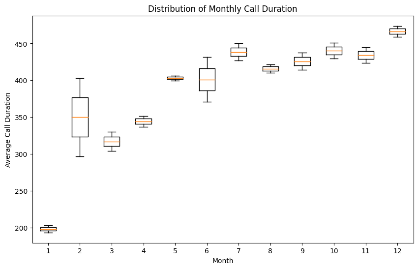

```python
# Plot a boxplot to visualize the distribution of the monthly call duration
plt.figure(figsize=(10, 6))
plt.boxplot([avg_duration_by_plan_month[avg_duration_by_plan_month['month'] == month]['total_minutes'] for month in avg_duration_by_plan_month['month'].unique()])
plt.xlabel('Month')
plt.ylabel('Average Call Duration')
plt.title('Distribution of Monthly Call Duration')
plt.xticks(range(1, len(avg_duration_by_plan_month['month'].unique()) + 1), avg_duration_by_plan_month['month'].unique())
plt.show()
```

```python
plan_users_counts_stats = plan_users_counts.pivot_table(index='plan_name', values=['total_minutes', 'total_messages_per_month', 'mb_used'],
                       aggfunc=['mean', 'std', 'var'])
plan_users_counts_stats
```

| plan_name | mean mb_used | mean total_messages_per_month | mean total_minutes | std mb_used | std total_messages_per_month | std total_minutes | var mb_used | var total_messages_per_month | var total_minutes |
| --- | --- | --- | --- | --- | --- | --- | --- | --- | --- |
| surf | 16558.776860 | 31.159568 | 428.749523 | 8013.516423 | 33.566717 | 234.453150 | 6.421645e+07 | 1126.724522 | 54968.279461 |
| ultimate | 17215.202778 | 37.551389 | 430.450000 | 7851.886627 | 34.767179 | 240.508762 | 6.165212e+07 | 1208.756744 | 57844.464812 |

```python
# Reviewer's code 4

plan_users_counts.pivot_table(index='plan_name', values=['total_minutes', 'total_messages_per_month', 'mb_used'],
                       aggfunc=['mean', 'std', 'var'])
```

| plan_name | mean mb_used | mean total_messages_per_month | mean total_minutes | std mb_used | std total_messages_per_month | std total_minutes | var mb_used | var total_messages_per_month | var total_minutes |
| --- | --- | --- | --- | --- | --- | --- | --- | --- | --- |
| surf | 16558.776860 | 31.159568 | 428.749523 | 8013.516423 | 33.566717 | 234.453150 | 6.421645e+07 | 1126.724522 | 54968.279461 |
| ultimate | 17215.202778 | 37.551389 | 430.450000 | 7851.886627 | 34.767179 | 240.508762 | 6.165212e+07 | 1208.756744 | 57844.464812 |

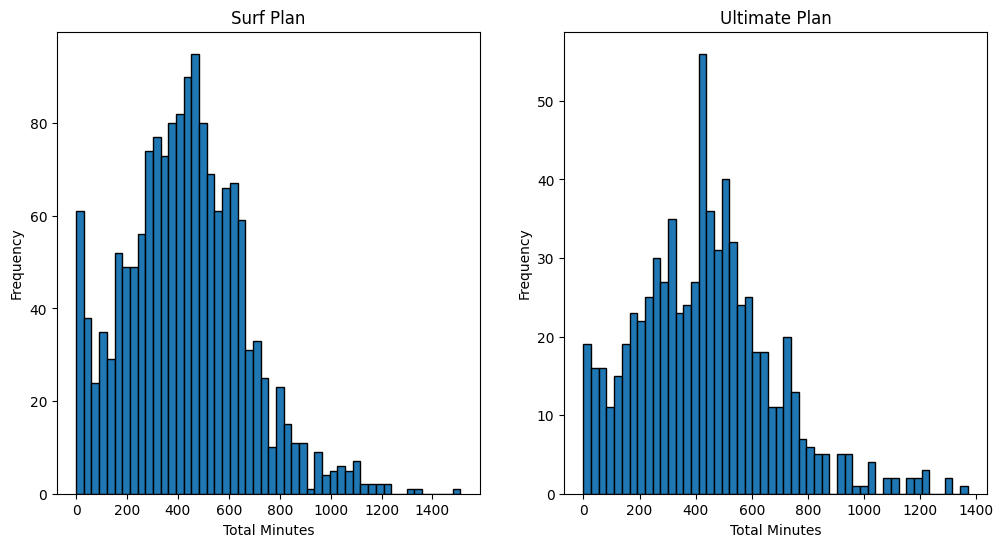

```python
import matplotlib.pyplot as plt

# Filter the data for Surf and Ultimate plans
surf_data = plan_users_counts[plan_users_counts['plan_name'] == 'surf']['total_minutes']
ultimate_data = plan_users_counts[plan_users_counts['plan_name'] == 'ultimate']['total_minutes']

# Create a figure and axis object
fig, ax = plt.subplots(1, 2, figsize=(12, 6))

# Create a histogram for Surf plan
ax[0].hist(surf_data, bins=50, edgecolor='black')
ax[0].set_title('Surf Plan')
ax[0].set_xlabel('Total Minutes')
ax[0].set_ylabel('Frequency')

# Create a histogram for Ultimate plan
ax[1].hist(ultimate_data, bins=50, edgecolor='black')
ax[1].set_title('Ultimate Plan')
ax[1].set_xlabel('Total Minutes')
ax[1].set_ylabel('Frequency')

# Show the plot
plt.show()
```

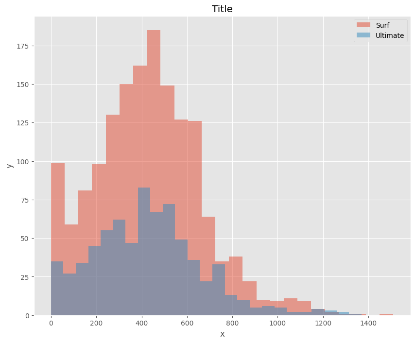

```python
# Reviewer's code 4

plt.style.use('ggplot') # Add style. You can put it in the very first cell, after plt is defined.

plan_users_counts.groupby('plan_name')['total_minutes'].plot.hist(alpha=0.5, legend=True, bins=25, figsize=(10,8))

plt.legend(['Surf', 'Ultimate'])
plt.title('Title')
plt.xlabel('x')
plt.ylabel('y')

plt.show()
```

```python
# Reviewer's code 2

plan_users_counts
```

|  | user_id | month | mb_used | total_minutes | total_messages_per_month | plan_name | messages_included | mb_per_month_included | minutes_included | usd_monthly_pay | usd_per_gb | usd_per_message | usd_per_minute |
| --- | --- | --- | --- | --- | --- | --- | --- | --- | --- | --- | --- | --- | --- |
| 0 | 1000 | 12 | 1902.0 | 124.0 | 11.0 | ultimate | 1000 | 30720 | 3000 | 70 | 7.0 | 0.01 | 0.01 |
| 1 | 1001 | 8 | 6920.0 | 182.0 | 30.0 | surf | 50 | 15360 | 500 | 20 | 10.0 | 0.03 | 0.03 |
| 2 | 1001 | 9 | 13315.0 | 315.0 | 44.0 | surf | 50 | 15360 | 500 | 20 | 10.0 | 0.03 | 0.03 |
| 3 | 1001 | 10 | 22331.0 | 393.0 | 53.0 | surf | 50 | 15360 | 500 | 20 | 10.0 | 0.03 | 0.03 |
| 4 | 1001 | 11 | 18505.0 | 426.0 | 36.0 | surf | 50 | 15360 | 500 | 20 | 10.0 | 0.03 | 0.03 |
| ... | ... | ... | ... | ... | ... | ... | ... | ... | ... | ... | ... | ... | ... |
| 2288 | 1498 | 12 | 23138.0 | 339.0 | 0.0 | surf | 50 | 15360 | 500 | 20 | 10.0 | 0.03 | 0.03 |
| 2289 | 1499 | 9 | 12985.0 | 346.0 | 0.0 | surf | 50 | 15360 | 500 | 20 | 10.0 | 0.03 | 0.03 |
| 2290 | 1499 | 10 | 19493.0 | 385.0 | 0.0 | surf | 50 | 15360 | 500 | 20 | 10.0 | 0.03 | 0.03 |
| 2291 | 1499 | 11 | 16814.0 | 308.0 | 0.0 | surf | 50 | 15360 | 500 | 20 | 10.0 | 0.03 | 0.03 |
| 2292 | 1499 | 12 | 22060.0 | 496.0 | 0.0 | surf | 50 | 15360 | 500 | 20 | 10.0 | 0.03 | 0.03 |

2293 rows × 13 columns

### Messages

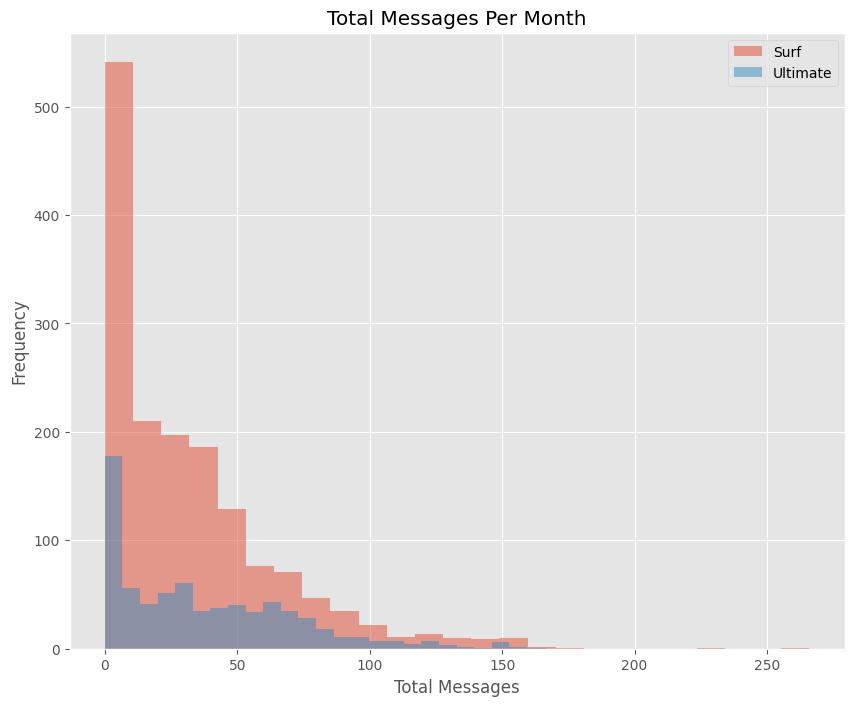

```python
# Compare the number of messages users of each plan tend to send each month
messages_by_plan_month = plan_users_counts.groupby(['plan_name', 'month'])['total_messages_per_month'].sum().reset_index()
stats = plan_users_counts.groupby('total_messages_per_month').agg(['mean', 'var','std']).reset_index()

#pivoted_data = messages_by_plan_month.pivot(index='month', columns='plan_name', values='total_messages_per_month')
#pivoted_data.plot(kind='bar', figsize=(10, 6))
#plt.xlabel('Month')
#plt.ylabel('Average Messages per Month')
#plt.title('Average Messages per Month by Plan')
#plt.legend(title='Plan Name')
#plt.show()


# Create a histogram of total_messages_per_month
#plt.hist(stats['total_messages_per_month'], bins=50, edgecolor='black')

# Set title and labels
#plt.title('Histogram of Total Messages per Month')
#plt.xlabel('Total Messages per Month')
#plt.ylabel('Frequency')

# Show the plot
#plt.show()



plt.style.use('ggplot') # Add style. You can put it in the very first cell, after plt is defined.

plan_users_counts.groupby('plan_name')['total_messages_per_month'].plot.hist(alpha=0.5, legend=True, bins=25, figsize=(10,8))

plt.legend(['Surf', 'Ultimate'])
plt.title('Total Messages Per Month')
plt.xlabel('Total Messages')
plt.ylabel('Frequency')

plt.show()
```

```
  plan_name       mb_used
0      surf  16558.776860
1  ultimate  17215.202778
```

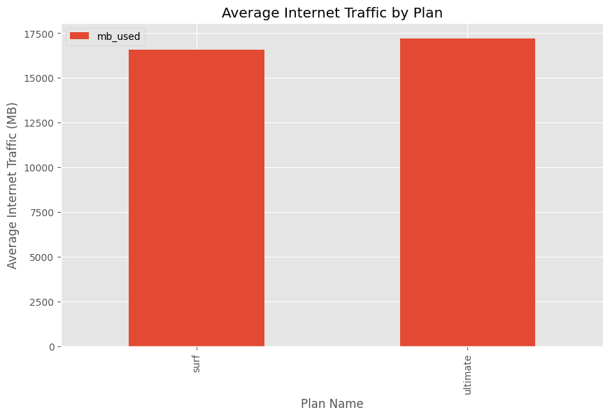

```python
internet_traffic_by_plan = plan_users_counts.groupby('plan_name')['mb_used'].mean().reset_index()
print(internet_traffic_by_plan)

internet_traffic_by_plan.plot(kind='bar', x='plan_name', y='mb_used', figsize=(10, 6))
plt.xlabel('Plan Name')
plt.ylabel('Average Internet Traffic (MB)')
plt.title('Average Internet Traffic by Plan')
plt.show()
```

### Internet

```
0        1902.0
1        6920.0
2       13315.0
3       22331.0
4       18505.0
         ...
2288    23138.0
2289    12985.0
2290    19493.0
2291    16814.0
2292    22060.0
Name: mb_used, Length: 2293, dtype: float64
```

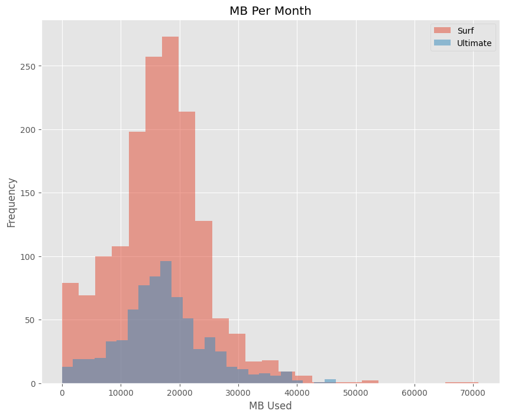

```python
#internet_merge = pd.merge(plan_users_counts, internet, on=['user_id', 'month','mb_used'], how='outer')

stats_internet = internet['mb_used'].agg(['mean', 'var','std']).reset_index()
print(plan_users_counts['mb_used'])



#plt.hist(plan_users_counts['mb_used'], bins=50, edgecolor='black')

# Set title and labels
#plt.title('Histogram of Total mb per Month')
#plt.xlabel('Total mb per Month')
#plt.ylabel('Frequency')

# Show the plot
plt.show()


plt.style.use('ggplot') # Add style. You can put it in the very first cell, after plt is defined.

plan_users_counts.groupby('plan_name')['mb_used'].plot.hist(alpha=0.5, legend=True, bins=25, figsize=(10,8))

plt.legend(['Surf', 'Ultimate'])
plt.title('MB Per Month')
plt.xlabel('MB Used')
plt.ylabel('Frequency')

plt.show()
```

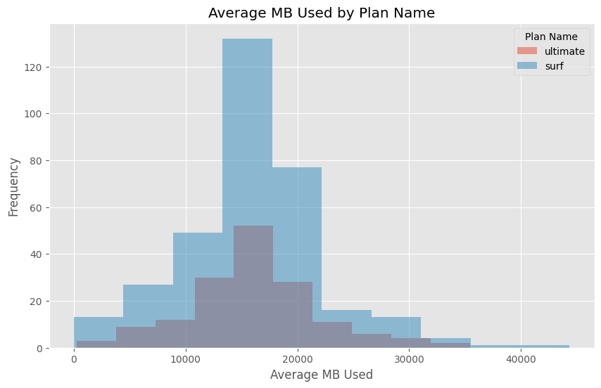

```python
internet_merge = pd.merge(plan_users_counts, internet, on=['user_id', 'month','mb_used'], how='outer')
grouped_internet_merge = internet_merge.groupby(['user_id', 'plan_name'])['mb_used'].mean().reset_index()

fig, ax = plt.subplots(figsize=(10, 6))
for plan in grouped_internet_merge['plan_name'].unique():
    plan_data = grouped_internet_merge[grouped_internet_merge['plan_name'] == plan]
    ax.hist(plan_data['mb_used'], alpha=0.5, label=plan)
ax.set_xlabel('Average MB Used')
ax.set_ylabel('Frequency')
ax.set_title('Average MB Used by Plan Name')
ax.legend(title='Plan Name')
plt.show()
```

```python
print(grouped_internet_merge['mb_used'].median())
print(grouped_internet_merge['mb_used'].mean())
```

```
15761.125
15923.078833377505
```

## Revenue

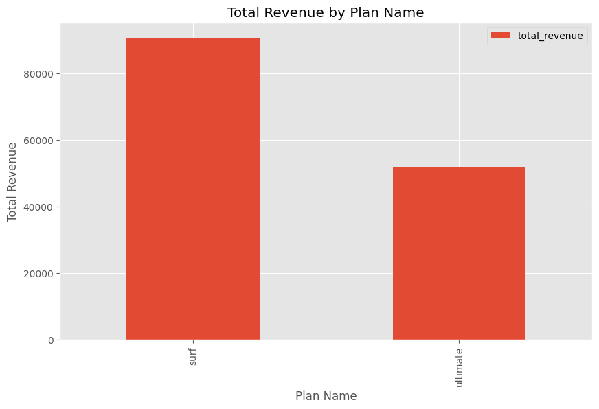

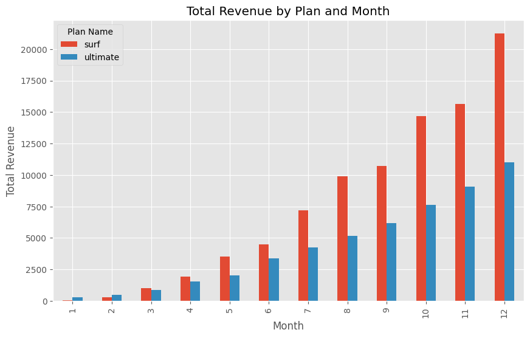

```python
plan_users_counts['revenue_messages'] = plan_users_counts.apply(lambda row: max(0, row['total_messages_per_month'] - row['messages_included']) * row['usd_per_message'], axis=1)
plan_users_counts['revenue_mb'] = plan_users_counts.apply(lambda row: max(0, row['mb_used'] - row['mb_per_month_included']) / 1024 * row['usd_per_gb'], axis=1)
plan_users_counts['revenue_minutes'] = plan_users_counts.apply(lambda row: max(0, row['total_minutes'] - row['minutes_included']) * row['usd_per_minute'], axis=1)
plan_users_counts['total_revenue'] = plan_users_counts['usd_monthly_pay'] + plan_users_counts['revenue_messages'] + plan_users_counts['revenue_mb'] + plan_users_counts['revenue_minutes']

plan_users_counts.groupby('plan_name')['total_revenue'].sum().reset_index()

grouped_data = plan_users_counts.groupby('plan_name')['total_revenue'].sum().reset_index()
grouped_data.plot(kind='bar', x='plan_name', y='total_revenue', figsize=(10, 6))
plt.xlabel('Plan Name')
plt.ylabel('Total Revenue')
plt.title('Total Revenue by Plan Name')
plt.show()

print()

pivoted_data = plan_users_counts.groupby(['plan_name', 'month'])['total_revenue'].sum().reset_index()
pivoted_data = pivoted_data.pivot(index='month', columns='plan_name', values='total_revenue')
pivoted_data.plot(kind='bar', figsize=(10, 6))
plt.xlabel('Month')
plt.ylabel('Total Revenue')
plt.title('Total Revenue by Plan and Month')
plt.legend(title='Plan Name')
plt.show()
```

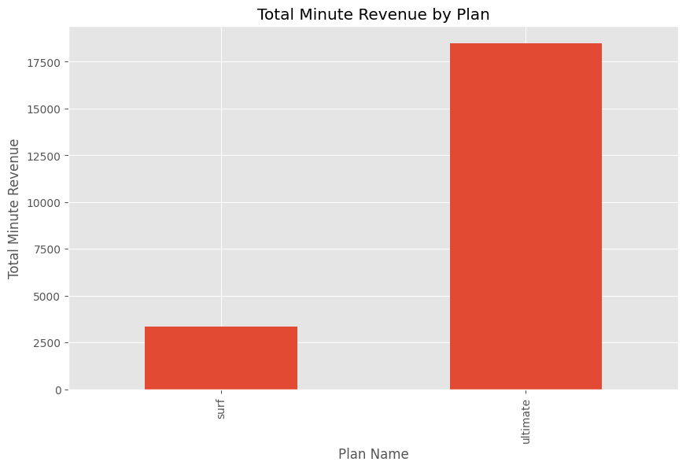

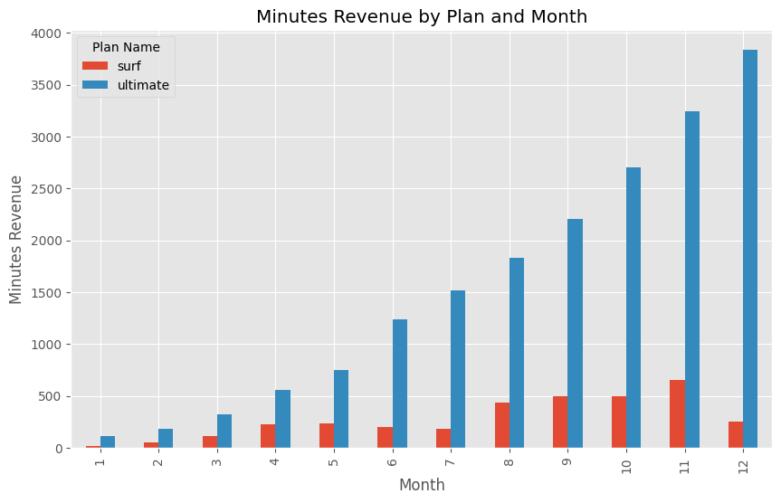

```python
# Calculate revenue_minutes
plan_users_counts['revenue_minutes'] = (plan_users_counts['minutes_included'] - plan_users_counts['total_minutes']) * plan_users_counts['usd_per_minute']

# Group the data by plan_name and calculate the sum of revenue_minutes
revenue_by_plan = plan_users_counts.groupby('plan_name')['revenue_minutes'].sum()

# Plot the histogram
plt.figure(figsize=(10, 6))
revenue_by_plan.plot(kind='bar')
plt.title('Total Minute Revenue by Plan')
plt.xlabel('Plan Name')
plt.ylabel('Total Minute Revenue')
plt.show()


pivoted_data = plan_users_counts.groupby(['plan_name', 'month'])['revenue_minutes'].sum().reset_index()
pivoted_data = pivoted_data.pivot(index='month', columns='plan_name', values='revenue_minutes')
pivoted_data.plot(kind='bar', figsize=(10, 6))
plt.xlabel('Month')
plt.ylabel('Minutes Revenue')
plt.title('Minutes Revenue by Plan and Month')
plt.legend(title='Plan Name')
plt.show()
```

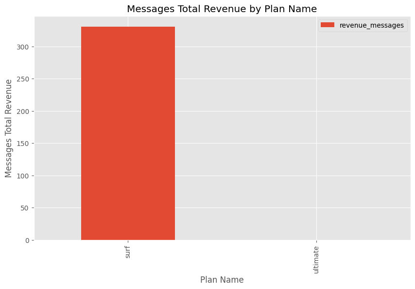

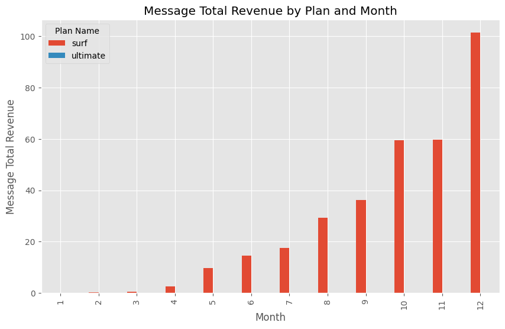

```python
plan_users_counts.groupby(['plan_name','month'])['revenue_messages'].sum().reset_index()

grouped_data = plan_users_counts.groupby('plan_name')['revenue_messages'].sum().reset_index()
grouped_data.plot(kind='bar', x='plan_name', y='revenue_messages', figsize=(10, 6))
plt.xlabel('Plan Name')
plt.ylabel('Messages Total Revenue')
plt.title('Messages Total Revenue by Plan Name')
plt.show()




pivoted_data = plan_users_counts.groupby(['plan_name', 'month'])['revenue_messages'].sum().reset_index()
pivoted_data = pivoted_data.pivot(index='month', columns='plan_name', values='revenue_messages')
pivoted_data.plot(kind='bar', figsize=(10, 6))
plt.xlabel('Month')
plt.ylabel('Message Total Revenue')
plt.title('Message Total Revenue by Plan and Month')
plt.legend(title='Plan Name')
plt.show()
```

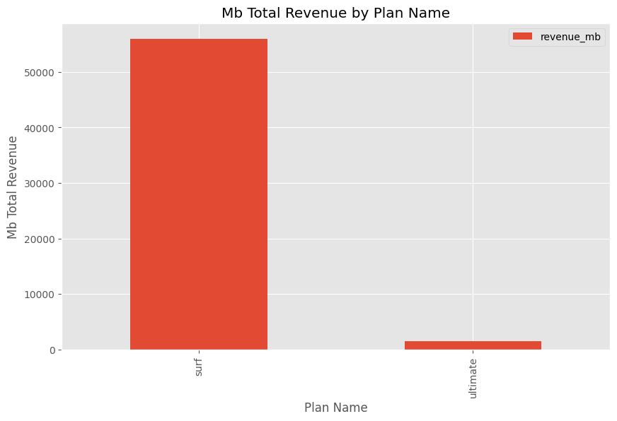

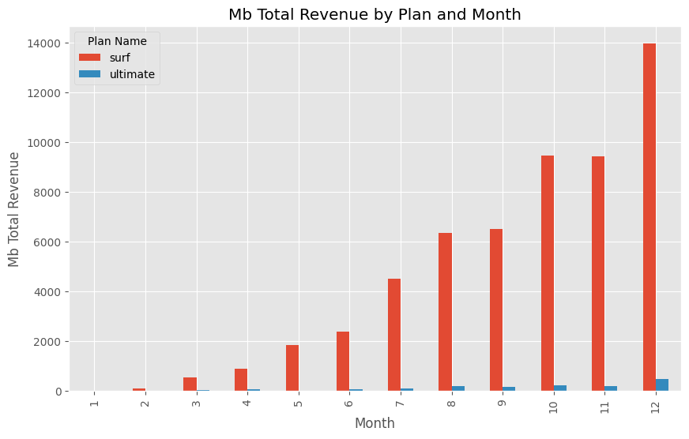

```python
plan_users_counts.groupby(['plan_name','month'])['revenue_mb'].sum().reset_index()

grouped_data = plan_users_counts.groupby('plan_name')['revenue_mb'].sum().reset_index()
grouped_data.plot(kind='bar', x='plan_name', y='revenue_mb', figsize=(10, 6))
plt.xlabel('Plan Name')
plt.ylabel('Mb Total Revenue')
plt.title('Mb Total Revenue by Plan Name')
plt.show()




pivoted_data = plan_users_counts.groupby(['plan_name', 'month'])['revenue_mb'].sum().reset_index()
pivoted_data = pivoted_data.pivot(index='month', columns='plan_name', values='revenue_mb')
pivoted_data.plot(kind='bar', figsize=(10, 6))
plt.xlabel('Month')
plt.ylabel('Mb Total Revenue')
plt.title('Mb Total Revenue by Plan and Month')
plt.legend(title='Plan Name')
plt.show()
```

[Formulate conclusions about how the revenue differs between the plans.]

## Test statistical hypotheses

[Test the hypothesis that the average revenue from users of the Ultimate and Surf calling plans differs.]

[Formulate the null and the alternative hypotheses, choose the statistical test, decide on the alpha value.]

```python
# Group the data by plan and user, and calculate the mean total revenue for each group
grouped_data = plan_users_counts.groupby(['plan_name', 'user_id'])['total_revenue'].mean().reset_index()

# Extract the mean total revenue for each plan
ultimate_revenue = grouped_data[grouped_data['plan_name'] == 'ultimate']['total_revenue']
surf_revenue = grouped_data[grouped_data['plan_name'] == 'surf']['total_revenue']

# Perform the two-sample t-test
results = st.ttest_ind(ultimate_revenue, surf_revenue, equal_var=False)


print('p-value:', results.pvalue)

alpha = 0.05

# Hypotheses:
# H0 (Null Hypothesis): The average revenue from users of the Ultimate and Surf calling plans is the same.
# H1 (Alternative Hypothesis): The average revenue from users of the Ultimate and Surf calling plans differs.

if (results.pvalue < alpha):
    print('Reject the null hypothesis: The average revenue from users of the Ultimate and Surf calling plans differs.')
else:
    print('Fail to reject the null hypothesis: The average revenue from users of the Ultimate and Surf calling plans does not differ.')
```

```
p-value: 3.600241990715484e-11
Reject the null hypothesis: The average revenue from users of the Ultimate and Surf calling plans differs.
```

```python
# Test the hypotheses
user_id_city = users[['user_id', 'city']]

merged_city = pd.merge(plan_users_counts, user_id_city, on=['user_id'], how='outer')

# Extract the city column
cities = merged_city['city']

# Create a mask to select cities in NY and NJ
ny_nj_mask = cities.str.contains('NY|NJ')
other_cities_mask = ~cities.str.contains('NY|NJ')

# Filter the DataFrame to select rows with cities in NY and NJ
ny_nj_cities = merged_city[ny_nj_mask]
other_cities = merged_city[other_cities_mask]

# Sort the resulting DataFrame by city
sorted_ny_nj_cities = ny_nj_cities.sort_values(by='city')
sorted_other_cities = other_cities.sort_values(by='city')


#average_total_rev_ny_nj = sorted_ny_nj_cities['total_revenue'].mean()
#print(average_total_rev_ny_nj)
#average_total_other_cities = sorted_other_cities['total_revenue'].mean()
#print(average_total_other_cities)
#sorted_ny_nj_cities_group = sorted_ny_nj_cities.groupby(['user_id','city'])['total_revenue'].sum().reset_index()
#print(sorted_ny_nj_cities_group)
#sorted_other_cities_group = sorted_other_cities.groupby(['user_id','city'])['total_revenue'].sum().reset_index()
#print(sorted_other_cities_group)
nynj = merged_city[merged_city.city.str.contains('NY-NJ')]['total_revenue']
not_nynj = merged_city[~merged_city.city.str.contains('NY-NJ')]['total_revenue']


alpha = .05

# Hypotheses:
# H0 (Null Hypothesis): The average revenue from users in the NY-NJ area is the same as that of users in other regions.
# H1 (Alternative Hypothesis): The average revenue from users in the NY-NJ area is significantly different from that of users in other regions.

total_results = st.ttest_ind(nynj, not_nynj, equal_var=False)

print('p-value:', total_results.pvalue)

# interpret the results
if (results.pvalue < alpha):
    print("Reject the null hypothesis: The average revenue from users in the NY-NJ area is significantly different from that of users in other regions.")
else:
    print("Fail to reject the null hypothesis: The average revenue from users in the NY-NJ area is not significantly different from that of users in other regions.")


# I chose to use the two-sample t-test (st.ttest_ind) because it is a suitable test for comparing the means of two independent samples (NY-NJ and other regions).
# I chose a significance level of 0.05 (alpha = 0.05) because it is a commonly used threshold for determining statistical significance.
```

[output not shown]

[List your important conclusions in this final section, make sure they cover all those important decisions (assumptions) that you've made and that led you to the way you processed and analyzed the data.]